# Week 4 Group Lab

## Modelling

- **4a.** Fit a linear model predicting total daily bike rentals from daily temperature. Write the linear model, interpret the slope and the intercept in context of the data.

```r
tempmodel <- lm(bike$cnt ~ bike$temp)
print(tempmodel)
```

```
##
## Call:
## lm(formula = bike$cnt ~ bike$temp)
##
## Coefficients:
## (Intercept)    bike$temp
##        1215          162
```

```r
#Looks like there is a positive relationship between temperature and
#bike rentals. Also even if temp=0 looks like some people still rent bikes.
```

- **4b.** Fit another linear model predicting total daily bike rentals from daily feeling temperature. Write the linear model, interpret the slope and the intercept in context of the data. Is temperature or feeling temperature a better predictor of bike rentals? Explain which criteria you used and why.

```r
atempmodel <- lm(bike$cnt ~ bike$atemp)
print(atempmodel)
```

```
##
## Call:
## lm(formula = bike$cnt ~ bike$atemp)
##
## Coefficients:
## (Intercept)   bike$atemp
##       945.8        150.0
```

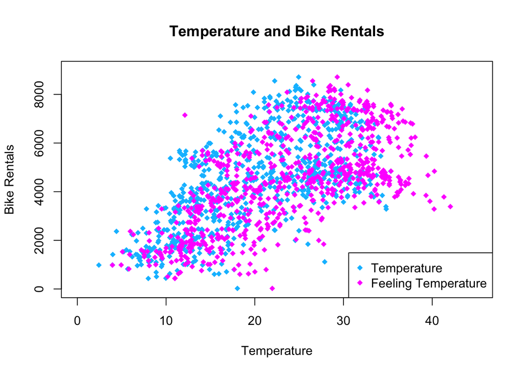

```r
#Looks like there is an even stronger positive
#relationship for feeling temperature than
#regular temperature. Again, even if temp=0 looks like
#some people still rent bikes. This time,

plot(x = bike$temp,
     y = bike$cnt,
     main = "Temperature and Bike Rentals",
     xlab = "Temperature",
     ylab = "Bike Rentals",
     xlim = c(0, 45),
     ylim = c(0, 9000),
     col = "deepskyblue",
     pch = 18)

points(x = bike$atemp, y = bike$cnt, xlim = c(0, 1),
     ylim = c(0, 9000), pch = 18, col = "magenta")

legend("bottomright",
legend = c("Temperature", "Feeling Temperature"),
col = c("deepskyblue", "magenta"),
pch = c(18, 18),
bg = "white"
)
```

```r
summary(tempmodel)$r.squared
```

```
## [1] 0.3937487
```

```r
summary(atempmodel)$r.squared
```

```
## [1] 0.3982439
```

```r
mean(bike$temp)
```

```
## [1] 20.31078
```

```r
mean(bike$atemp)
```

```
## [1] 23.7177
```

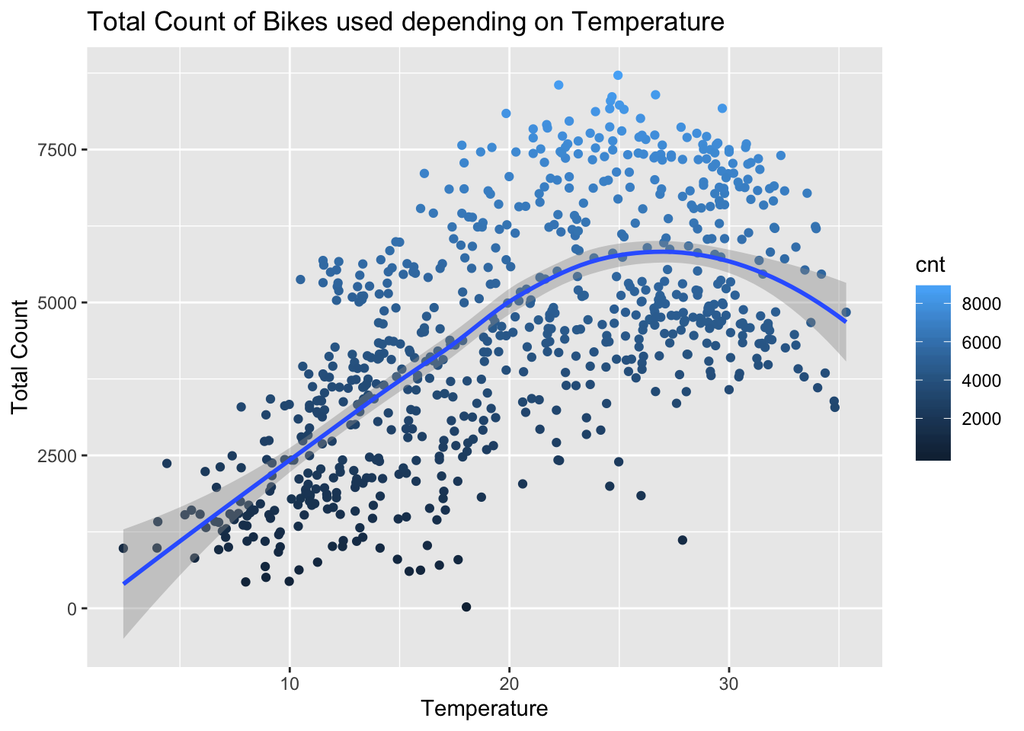

```r
#Overall looking at the plots and r squared values of the regressions,
#temp and feeling temp are pretty similar. There are some minor
#differences, however. The feeling temp tends to result in a higher
#number of bike rentals and feeling temperature is slightly more predictive of
#bike rentals based on the r squared value.
#It's also worth mentioning that increasing temperatutre only helps bike rentals up to a point,
#after it reaches ~24 the marginal benefit of higher temperature starts to plateu and even decline.
#This trend is clear in the plot below.

ggplot (bike, aes( x= temp, y = cnt, colour = cnt))+geom_point()+geom_smooth()+xlab("Temperature") + ylab ("Total Count")+ggtitle("Total Count of Bikes used depending on Temperature")
```

- **4c.** Fit another linear model predicting total daily bike rentals from year. Write the linear model, interpret the coefficients associated with different years.

```r
yearmodel <- lm(bike$cnt ~ bike$yr)
print(yearmodel)
```

```
##
## Call:
## lm(formula = bike$cnt ~ bike$yr)
##
## Coefficients:
## (Intercept)      bike$yr
##        3406         2194
```

```r
#Given that the regression has a positive slope,
#we can see that there has been an increase in bike rentals from 2011 to 2012.
#Based on the slope, 2012 had 2194 more bike rentals than 2011.
```

- **4d.** Fit a model predicting total daily bike rentals from season, year, whether the day is holiday or not, whether the day is a workingday or not, the weather category, temperature, feeling temperature, humidity and windspeed, as well as the interaction between at least one numerical and one categorical variable.

```r
bike$season=factor(bike$season,levels=c("spring", "summer", "fall", "winter"), ordered=FALSE)

multipleregression <- lm(cnt ~ season + yr + holiday +
      weathersit + temp + atemp + hum + windspeed + season*temp, data = bike)
summary(multipleregression)
```

```
##
## Call:
## lm(formula = cnt ~ season + yr + holiday + weathersit + temp +
##     atemp + hum + windspeed + season * temp, data = bike)
##
## Residuals:
##     Min      1Q  Median      3Q     Max
## -3218.1  -335.6    44.0   456.8  2926.2
##
## Coefficients:
##                         Estimate Std. Error t value Pr(>|t|)
## (Intercept)             1484.278    232.981   6.371 3.36e-10 ***
## seasonsummer            1693.218    303.586   5.577 3.46e-08 ***
## seasonfall              8393.901    572.287  14.667  < 2e-16 ***
## seasonwinter            1005.437    282.783   3.556 0.000402 ***
## yr                      1997.474     55.050  36.285  < 2e-16 ***
## holiday                 -650.684    162.154  -4.013 6.63e-05 ***
## weathersit2:Mist        -449.055     72.348  -6.207 9.15e-10 ***
## weathersit3:Light Snow -2019.173    184.780 -10.927  < 2e-16 ***
## temp                     163.150     34.712   4.700 3.12e-06 ***
## atemp                      9.628     27.523   0.350 0.726590
## hum                      -19.427      2.655  -7.317 6.82e-13 ***
## windspeed                -45.433      5.816  -7.812 2.00e-14 ***
## seasonsummer:temp        -45.944     17.234  -2.666 0.007851 **
## seasonfall:temp         -288.237     23.045 -12.507  < 2e-16 ***
## seasonwinter:temp         19.196     18.314   1.048 0.294919
## ---
## Signif. codes:  0 '***' 0.001 '**' 0.01 '*' 0.05 '.' 0.1 ' ' 1
##
## Residual standard error: 729.1 on 716 degrees of freedom
## Multiple R-squared:  0.8611, Adjusted R-squared:  0.8584
## F-statistic:   317 on 14 and 716 DF,  p-value: < 2.2e-16
```

- **4e.** Interpret slope coefficients associated with two of the interacting variables in your model in context of the data. Note: If one of these is categorical with multiple levels, make sure you interpret all of the slope coefficients associated with the levels of the variable.

- **4f.**. Based on the model you found in the previous questions, discuss what makes for a good day to bike in DC (as measured by rental bikes being more in demand).

Your answer here: #A good day is a day in the fall without snow. These two have the biggest impact according to my regression.